# P6_Chadeau_notebook3_analyse_univ_categ_price_date

```python
from IPython.core.display import display, HTML
f = open("P6_Chadeau_notebook3_sommaire.html", "r", encoding="utf-8")
display(HTML(f.read()))
```

TOP  
Importation des librairies et fichiers  
Déclaration des fonctions  
Importation dataframe  
La mission

- Analyses univariées

- Variable qualitative 'categ'

- Variable quantitative 'price'

- Analyse des tops et des flops entre mars 2021 et février 2023

Suite du projet : Analyses univariées (suite)

# Projet 6 -Analysez les ventes d'une librairie avec R ou Python

[figure not shown]

## NOTEBOOK 3 - ANALYSES UNIVARIEES

### Importation des librairies et fichiers

```python
import pandas as pd
import numpy as np
import re
import matplotlib.pyplot as plt
import seaborn as sns
import datetime
from statsmodels.tsa.stattools import adfuller

#Permet d'afficher toutes les lignes d'une liste
pd.set_option("max_rows", None)

#Permet l'affichage de tous les résultats d'une cellule (pas seulement le dernier)
from IPython.core.interactiveshell import InteractiveShell
InteractiveShell.ast_node_interactivity = "all"

#Permet de définir des paramètres d'affichage pour l'ensemble des graphiques
from pylab import rcParams
rcParams['figure.figsize'] = 15, 5
```

### Déclaration des fonctions

```python
class graphic():
    def lorenz_gini(data,title,medial,mediane):

        n = len(data)
        #Tri des individus dans l'ordre croissant des valeurs de la variable + calcul de la somme cumulée
        #et division par la somme des observations afin que le haut de la courbe soit à 1
        lorenz = np.cumsum(np.sort(data)) / data.sum()
        lorenz = np.append([0],lorenz)

        fig = plt.figure(figsize=(6, 6))
        memo=plt.axes().axis('equal')
        xaxis=np.linspace(0,1,len(lorenz))

        plt.plot(xaxis,lorenz,'blue', label='M')
        memo=plt.axis([0, 1, 0, 1])

        memo=plt.plot([0, 1], [0, 1], 'r-', lw=2, label='Première bissectrice (distribution égalitaire)')
        memo=plt.xlim(0, 1)
        memo=plt.vlines(x=medial, ymin=0, ymax=0.5, color='blue', linestyle='--', linewidth=1, label='Médial')
        memo=plt.hlines(xmin=medial, xmax=0, y=0.5, color='blue', linestyle='--', linewidth=1)
        memo=plt.vlines(x=0.5, ymin=0, ymax=mediane, color='green', linestyle='--', linewidth=1, label='Médiane')
        memo=plt.hlines(xmin=0, xmax=0.5, y=mediane, color='green', linestyle='--', linewidth=1)
        memo=plt.title(title)
        memo=plt.xlabel("Distribution (%)")
        memo=plt.ylabel("Cumul (%)")
        memo=plt.legend()
        memo=plt.legend()
        memo=plt.show()

        #Calcul du coefficient de Gini
        # Surface sous la courbe de Lorenz.
        AUC = (lorenz.sum() -lorenz[-1]/2 -lorenz[0]/2)/n
        # Surface entre la première bissectrice et le courbe de Lorenz
        S = 0.5 - AUC
        gini = 2*S
        print("Indice de Gini :", round(gini,2))
```

### Importation dataframe

```python
#Import du fichier 'join_final', jointure des 3 dataframes customers, products et transactions

df_ca=pd.read_csv("join_final.csv")
df_ca['date']= pd.to_datetime(df_ca['date'],errors = 'coerce')
df_ca['birth']=df_ca['birth'].astype('Int64')
df_ca['Age']=df_ca['Age'].astype('Int64')
df_ca['mois']=df_ca['date'].dt.month

#Le dataframe est indexé sur la colonne 'date' afin de pouvoir travailler sur la série temporelle
#en terme de période
df_ca.set_index('date', inplace=True)
```

```python
#Import du fichier 'products_clean'
df_products_clean=pd.read_csv("products_clean.csv")
```

## Partie 3 - La mission (suite)

### **Variable qualitative 'categ'**

**==>Analyse de la distribution de la variable catégorie dans les produits proposés**

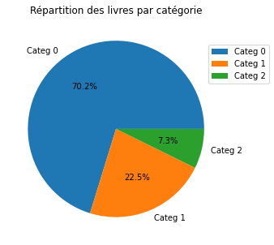

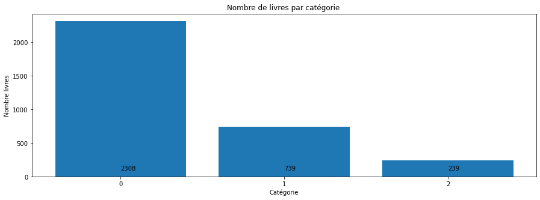

```python
#Répartition Nombre de livres par catégorie
df_prod_categ=df_products_clean.groupby('categ').count().reset_index()
x=df_prod_categ['id_prod']
mem=plt.pie(x,labels=['Categ 0','Categ 1','Categ 2'],autopct='%1.1f%%',normalize = True)
mem=plt.title("Répartition des livres par catégorie")
mem=plt.legend(loc="upper left",bbox_to_anchor=(0.9,0.9))
memo=plt.show()

memo=plt.bar(['0','1','2'], df_prod_categ['id_prod'])
titre="Nombre de livres par catégorie "
memo=plt.title(titre)
memo=plt.xlabel("Catégorie")
memo=plt.ylabel("Nombre livres")
memo=plt.text(0,100,df_prod_categ.iloc[0,2])
memo=plt.text(1,100,df_prod_categ.iloc[1,2])
memo=plt.text(2,100,df_prod_categ.iloc[2,2])


memo=plt.show()
```

**==>Analyse de la distribution de la variable catégorie dans les produits vendus**

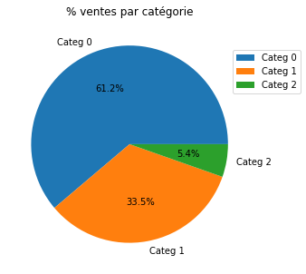

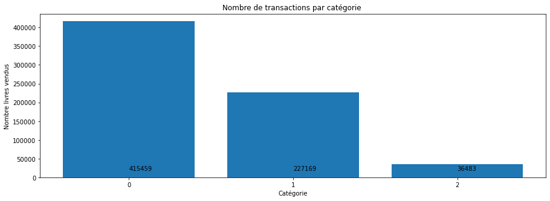

```python
#Nombre de transactions par catégorie
mem=plt.subplot(1, 2, 2)
df_ca_categ=df_ca.groupby('categ').count().reset_index()
x=df_ca_categ['price']
mem=plt.pie(x,labels=['Categ 0','Categ 1','Categ 2'],autopct='%1.1f%%',normalize = True)
mem=plt.title("% ventes par catégorie")
mem=plt.legend(loc="upper left",bbox_to_anchor=(0.9,0.9))
mem=plt.show()

#Nombre de transactions par catégorie
df_ca_prod=df_ca.groupby('categ').count().reset_index()
memo=plt.bar(['0','1','2'], df_ca_prod['id_prod'])
titre="Nombre de transactions par catégorie "
memo=plt.title(titre)
memo=plt.xlabel("Catégorie")
memo=plt.ylabel("Nombre livres vendus")
memo=plt.text(0,20000,df_ca_prod.iloc[0,2])
memo=plt.text(1,20000,df_ca_prod.iloc[1,2])
memo=plt.text(2,20000,df_ca_prod.iloc[2,2])
memo=plt.show()
```

**==>Analyse de la distribution de la variable catégorie dans le chiffre d'affaires**

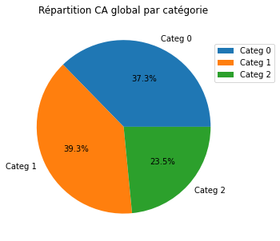

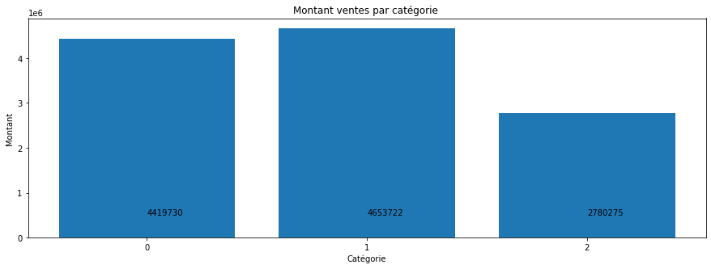

```python
#Répartition CA global par catégorie
mem=plt.subplot(1, 2, 2)
df_ca_categ=df_ca.groupby('categ').sum().reset_index()
x=df_ca_categ['price']
mem=plt.pie(x,labels=['Categ 0','Categ 1','Categ 2'],autopct='%1.1f%%',normalize = True)
mem=plt.title("Répartition CA global par catégorie")
mem=plt.legend(loc="upper left",bbox_to_anchor=(0.9,0.9))
memo=plt.show()


#CA par catégorie
df_ca_prod=df_ca.groupby('categ').sum().reset_index()
memo=plt.bar(['0','1','2'], df_ca_prod['price'])
titre="Montant ventes par catégorie "
memo=plt.title(titre)
memo=plt.xlabel("Catégorie")
memo=plt.ylabel("Montant")
memo=plt.text(0,500000,int(df_ca_prod.iloc[0,2]))
memo=plt.text(1,500000,int(df_ca_prod.iloc[1,2]))
memo=plt.text(2,500000,int(df_ca_prod.iloc[2,2]))
memo=plt.show()
```

On constate :  
==> catégorie 0 :

le plus grand nombre de livres proposé (70,2%)

le plus grand nombre de livres vendus (61,2%)

37,3% du chiffre d'affaires

==> catégorie 1 :

22,5% des livres proposés

33,5% des livres vendus

la plus grande part du chiffre d'affaires (39,3%)

==> catégorie 2 :

7,3% des livres proposés

5,4% des livres vendus

23,5% du chiffre d'affaires

==> Même si les livres issus de la catégorie 2 ne représentent que 5,4% des livres vendus, ils représentent quasiment 25% du CA! Le catalogue concernant les livres de cette catégorie devrait être élargi.

**==> Décomposition CA par période et par catégorie**

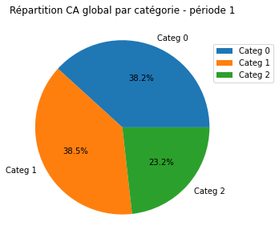

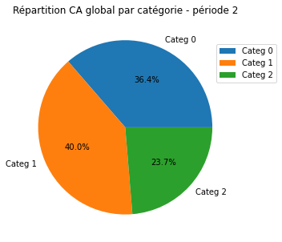

```python
#Répartition CA global par catégorie et par période

df1=df_ca.loc[df_ca.index < '2022-03-01']
df2=df_ca.loc[df_ca.index > '2022-03-01']

mem=plt.subplot(1, 2, 2)
df_ca_categ=df1.groupby('categ').sum().reset_index()
x=df_ca_categ['price']
mem=plt.pie(x,labels=['Categ 0','Categ 1','Categ 2'],autopct='%1.1f%%',normalize = True)
mem=plt.title("Répartition CA global par catégorie - période 1")
mem=plt.legend(loc="upper left",bbox_to_anchor=(0.9,0.9))
plt.savefig("CAcatper1.png")
memo=plt.show()


mem=plt.subplot(1, 2, 2)
df_ca_categ=df2.groupby('categ').sum().reset_index()
x=df_ca_categ['price']
mem=plt.pie(x,labels=['Categ 0','Categ 1','Categ 2'],autopct='%1.1f%%',normalize = True)
mem=plt.title("Répartition CA global par catégorie - période 2")
mem=plt.legend(loc="upper left",bbox_to_anchor=(0.9,0.9))
plt.savefig("CAcatper2.png")
memo=plt.show()
```

Répartition quasiment équivalente entre les 2 périodes avec :  
- moins de ventes pour la catégorie 0 en période 2  
- plus de ventes pour la catégorie 1 en période 2

### **Variable quantitative 'price'**

**==> Calculs mesures de dispersion et de forme**

```python
#Analyse descriptive de la variable 'price'
#Moyenne, médiane, mode, minimum, maximum, Variance, Ecart type, Skewness,Kurtosis
print("Moyenne des prix = ",round(df_products_clean['price'].mean(), 2),"€")
print("Médiane des prix = ",round(df_products_clean['price'].median(), 2),"€")
print("Mode des prix = ",df_products_clean['price'].mode()[0],"€")
print("Minimum des prix = ",df_products_clean['price'].min(),"€")
print("Maximum des prix = ",df_products_clean['price'].max(),"€")
print("Variance des prix (σ2) = ",round(df_products_clean['price'].var(ddof=0),2),"€")
print("Ecart type des prix (σ) = ",round(df_products_clean['price'].std(ddof=0),2),"€")
print("Skewness = ",round(df_products_clean['price'].skew(),2))
print("Kurtosis = ",round(df_products_clean['price'].kurt(),2))
```

```
Moyenne des prix =  21.86 €
Médiane des prix =  13.07 €
Mode des prix =  4.99 €
Minimum des prix =  0.62 €
Maximum des prix =  300.0 €
Variance des prix (σ2) =  890.74 €
Ecart type des prix (σ) =  29.85 €
Skewness =  3.8
Kurtosis =  17.95
```

**==>Analyse de la distribution des prix dans les produits**

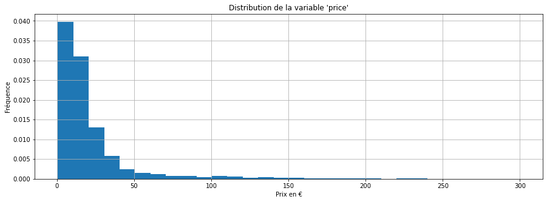

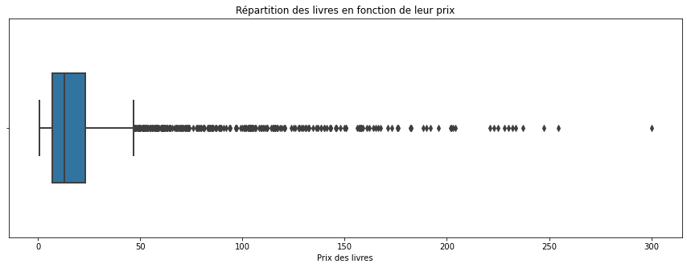

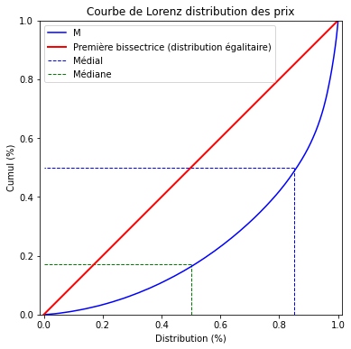

```
Indice de Gini : 0.53
```

```python
#Distribution via histogramme
memo=df_products_clean['price'].hist(density=True, bins=30)
memo=plt.title("Distribution de la variable 'price'")
memo=plt.xlabel("Prix en €")
memo=plt.ylabel("Fréquence")
memo=plt.show()

#Distribution des livres en fonction de leur prix : boxplot
memo=sns.boxplot(x='price', data=df_products_clean, width = 0.5, linewidth = 2,orient='h')
memo=plt.xlabel('Prix des livres')
memo=plt.title('Répartition des livres en fonction de leur prix')
memo=plt.show()

Q1=df_products_clean['price'].quantile(0.25)
Q2=df_products_clean['price'].quantile(0.5)
Q3=df_products_clean['price'].quantile(0.75)
IQ=Q3-Q1
MAX=Q3+1.5*IQ
MIN=Q1-1.5*IQ
IQdroite=Q3-Q2
IQgauche=Q2-Q1


#Distribution des prix : courbe de Lorenz
graphic.lorenz_gini(df_products_clean['price'],"Courbe de Lorenz distribution des prix",0.85,0.17)
```

La distribution des prix n'est pas une distribution normale (la moyenne, la médiane et le mode ne sont pas identiques) : on voit clairement sur l'ensemble des figures que la distribution est très étalée vers la droite, asymétrie confirmée par l'indicateur skewness.  
La distribution des prix n'est pas égalitaire :  
50% des livres représentent 17% des prix, 50% des livres sont des livres peu chers  
Les prix les plus présents dans la base : prix < 10 euros  
75% des livres coûtent moins de 22.99 €  
50% des livres coûtent entre 6.99 € et 22.99 €  
Il y a des valeurs extrêmes mais pas aberrantes : les prix ne vont pas au delà de 300€ ce qui peut être normal en fonction du type de livre.

**==>distribution de la variable prix par catégorie**

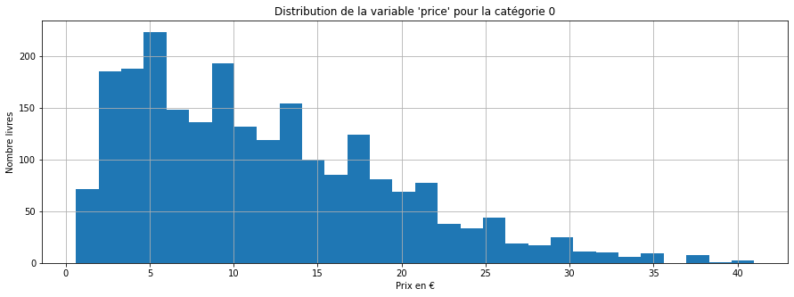

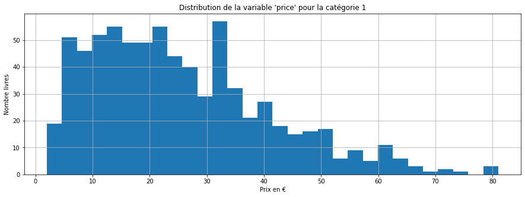

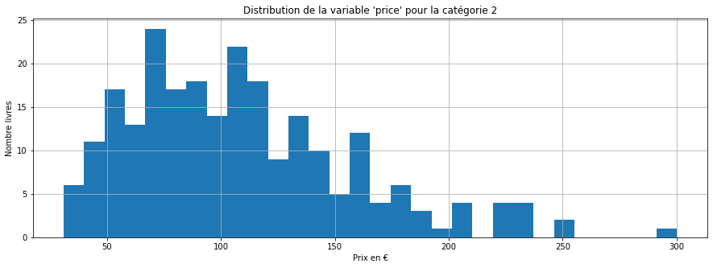

```python
#Répartition des prix par catégorie
nblivtotal=df_products_clean.count()['id_prod']
pourcent=[]
for i in [0, 1, 2]:
    memo=df_products_clean.loc[df_products_clean['categ']==i]['price'].hist(bins=30)
    titre="Distribution de la variable 'price' pour la catégorie " + str(i)
    memo=plt.title(titre)
    memo=plt.xlabel("Prix en €")
    memo=plt.ylabel("Nombre livres")
    memo=plt.show()
    nblivcateg=df_products_clean[df_products_clean['categ']==i]['price'].count()
    pourcent.append(round(nblivcateg/nblivtotal*100,2))
```

**==>distribution de la variable prix par catégorie (boxplot)**

```
Prix minimum categ 0  :  0.62 €
Prix maximum categ 0  :  40.99 €
Médiane categ 0  :  10.32 €
Moyenne categ 0  :  11.73 €
75% des livres de la categ 0 coûtent moins de 16.66 €

Prix minimum categ 1  :  2.0 €
Prix maximum categ 1  :  80.99 €
Médiane categ 1  :  22.99 €
Moyenne categ 1  :  25.53 €
75% des livres de la categ 1 coûtent moins de 33.99 €

Prix minimum categ 2  :  30.99 €
Prix maximum categ 2  :  300.0 €
Médiane categ 2  :  101.99 €
Moyenne categ 2  :  108.35 €
75% des livres de la categ 2 coûtent moins de 136.53 €
```

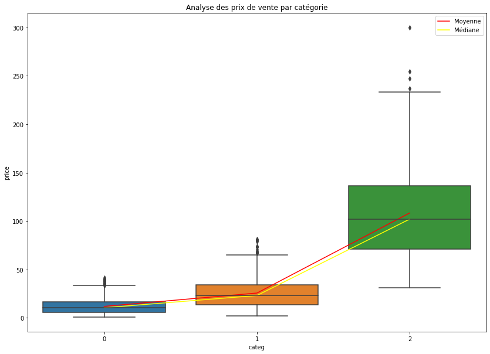

```python
mem=plt.figure(figsize=(14,10))

memo=sns.boxplot(x = 'categ', y = 'price', data = df_products_clean)
memo=plt.title('Analyse des prix de vente par catégorie')

moy=[]
med=[]
for i in[0,1,2]:
    Q1=df_products_clean[df_products_clean['categ']==i]['price'].quantile(0.25)
    Q2=df_products_clean[df_products_clean['categ']==i]['price'].quantile(0.5)
    Q3=df_products_clean[df_products_clean['categ']==i]['price'].quantile(0.75)
    prixmini=df_products_clean[df_products_clean['categ']==i]['price'].min()
    prixmaxi=df_products_clean[df_products_clean['categ']==i]['price'].max()
    IQ=Q3-Q1
    MAX=Q3+1.5*IQ
    MIN=Q1-1.5*IQ
    IQdroite=Q3-Q2
    IQgauche=Q2-Q1
    moy.append(round(df_products_clean[df_products_clean['categ']==i]['price'].mean(),2))
    med.append(Q2)
    print("\nPrix minimum categ",str(i)," : ",prixmini,"€")
    print("Prix maximum categ",str(i)," : ",prixmaxi,"€")
    print("Médiane categ",str(i)," : ",Q2,"€")
    print("Moyenne categ",str(i)," : ",round(df_products_clean[df_products_clean['categ']==i]['price'].mean(),2),"€")
    print("75% des livres de la categ",str(i),"coûtent moins de",round(Q3,2),"€")


x=[0,1,2]
memo=plt.plot(x, moy,color='red',label="Moyenne")
memo=plt.plot(x, med,color='yellow',label="Médiane")
memo=plt.legend()
memo=plt.show()
```

### **Analyse des tops et des flops entre mars 2021 et février 2023**

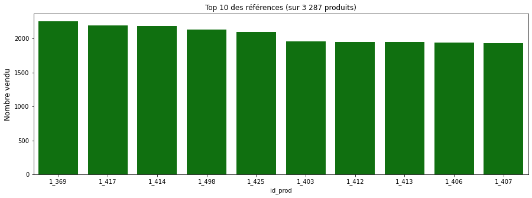

|  | id_prod | categ | price | Nombre vendu |
| --- | --- | --- | --- | --- |
| 0 | 1_369 | 1 | 23.99 | 2252 |
| 1 | 1_417 | 1 | 20.99 | 2189 |
| 2 | 1_414 | 1 | 23.83 | 2180 |
| 3 | 1_498 | 1 | 23.37 | 2128 |
| 4 | 1_425 | 1 | 16.99 | 2096 |
| 5 | 1_403 | 1 | 17.99 | 1960 |
| 6 | 1_412 | 1 | 16.65 | 1951 |
| 7 | 1_413 | 1 | 17.99 | 1945 |
| 8 | 1_406 | 1 | 24.81 | 1939 |
| 9 | 1_407 | 1 | 15.99 | 1935 |

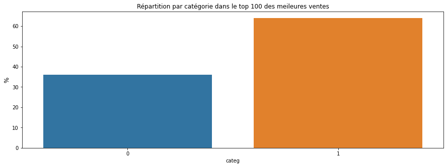

```python
#Analyse des tops et des flops
df_temp=df_ca.copy()


#Les tops

df_top=df_temp.groupby(['id_prod','categ','price']).size().sort_values(ascending=False).head(10).reset_index(name="Nombre vendu")

#Affichage du graphique
mem=plt.figure(figsize=(15,5))
mem=sns.barplot(x='id_prod',y='Nombre vendu',data=df_top,color='green')
mem=plt.title("Top 10 des références (sur 3 287 produits)")
mem=plt.ylabel('Nombre vendu', fontsize=12)
mem=plt.show()
df_top

#Analyse catégorie "star" dans les 100 premiers produits
df_memo=df_temp.groupby(['id_prod','categ']).size().sort_values(ascending=False).head(100).reset_index(name="Nombre vendu")
df_top_100=df_memo.groupby(['categ']).size().sort_values(ascending=False).reset_index(name="Nombre categ")
mem=plt.figure(figsize=(15,5))
mem=sns.barplot(x='categ',y='Nombre categ',data=df_top_100)
mem=plt.title("Répartition par catégorie dans le top 100 des meileures ventes")
mem=plt.ylabel('%', fontsize=12)
mem=plt.show()
```

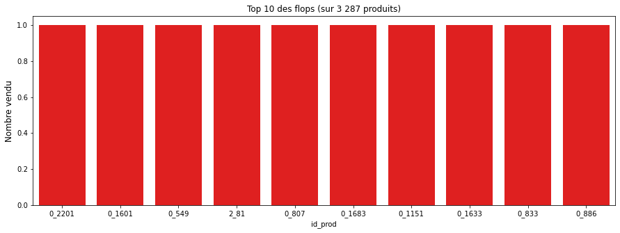

|  | id_prod | categ | price | Nombre vendu |
| --- | --- | --- | --- | --- |
| 0 | 0_2201 | 0 | 20.99 | 1 |
| 1 | 0_1601 | 0 | 1.99 | 1 |
| 2 | 0_549 | 0 | 2.99 | 1 |
| 3 | 2_81 | 2 | 86.99 | 1 |
| 4 | 0_807 | 0 | 1.99 | 1 |
| 5 | 0_1683 | 0 | 2.99 | 1 |
| 6 | 0_1151 | 0 | 2.99 | 1 |
| 7 | 0_1633 | 0 | 24.99 | 1 |
| 8 | 0_833 | 0 | 2.99 | 1 |
| 9 | 0_886 | 0 | 21.82 | 1 |

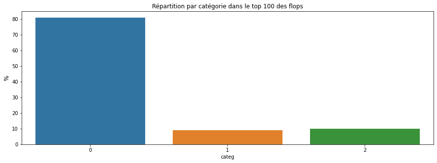

```python
#Les flops
df_flop=df_temp.groupby(['id_prod','categ','price']).size().sort_values(ascending=True).head(10).reset_index(name="Nombre vendu")
#Affichage du graphique
mem=plt.figure(figsize=(15,5))
mem=sns.barplot(x='id_prod',y='Nombre vendu',data=df_flop,color='red')
mem=plt.title("Top 10 des flops (sur 3 287 produits)")
mem=plt.ylabel('Nombre vendu', fontsize=12)
mem=plt.show()
df_flop


#Analyse catégorie "star" dans les 100 premiers produits
df_memo=df_temp.groupby(['id_prod','categ']).size().sort_values(ascending=True).head(100).reset_index(name="Nombre vendu")
df_flop_100=df_memo.groupby(['categ']).size().sort_values(ascending=False).reset_index(name="Nombre categ")
mem=plt.figure(figsize=(15,5))
mem=sns.barplot(x='categ',y='Nombre categ',data=df_flop_100)
mem=plt.title("Répartition par catégorie dans le top 100 des flops")
mem=plt.ylabel('%', fontsize=12)
mem=plt.show()
```

Suite du projet : Analyses univariées (suite)